# Question 4: (Processing)

## Workflow for Q4

```
             New Q4 Notebook
                   │
                   ▼
             Start Spark
                   │
                   ▼
      Read Q3(e) Parquet output
                   │
                   ▼
            stations_saved
                   │
                   ▼
            Q4 Notebook
            │
            ├── 1. Spark setup
            │
            ├── 2. Configuration / paths
            │
            ├── 3. Load Q3 enriched dataset
            │
            ├── 4. Validate input
            │
            ├── 5. Q4(a)
            │
            ├── 6. Q4(b)
            │
            ├── 7. Q4(c)
            │
            └── 8. Performance / validation
```

## 1. Spark Setup

```python
# Run this cell to import pyspark and to define start_spark() and stop_spark()

import findspark

findspark.init()

import getpass
import pandas
import pyspark
import random
import re

from IPython.display import display, HTML
from pyspark import SparkContext
from pyspark.sql import SparkSession


# Constants used to interact with Azure Blob Storage using the hdfs command or Spark

global username

username = re.sub('@.*', '', getpass.getuser())

global azure_account_name
global azure_data_container_name # where data is stored for the assignment
global azure_user_container_name # where users who are doing the assignment can save their outputs
global azure_user_token # which is required for read/write access


# These are pre-defined and you don't need to change this
azure_account_name = "madsstorage002"
azure_data_container_name = "campus-data"
azure_user_container_name = "campus-user"
azure_user_token = r""


# Functions used below

def dict_to_html(d):
    """Convert a Python dictionary into a two column table for display.
    """

    html = []

    html.append(f'<table width="100%" style="width:100%; font-family: monospace;">')
    for k, v in d.items():
        html.append(f'<tr><td style="text-align:left;">{k}</td><td>{v}</td></tr>')
    html.append(f'</table>')

    return ''.join(html)


def show_as_html(df, n=20):
    """Leverage existing pandas jupyter integration to show a spark dataframe as html.

    Args:
        n (int): number of rows to show (default: 20)
    """

    display(df.limit(n).toPandas())


def display_spark():
    """Display the status of the active Spark session if one is currently running.
    """

    if 'spark' in globals() and 'sc' in globals():

        name = sc.getConf().get("spark.app.name")

        html = [
            f'<p><b>Spark</b></p>',
            f'<p>The spark session is <b><span style="color:green">active</span></b>, look for <code>{name}</code> under the running applications section in the Spark UI.</p>',
            f'<ul>',
            f'<li><a href="http://localhost:{sc.uiWebUrl.split(":")[-1]}" target="_blank">Spark Application UI</a></li>',
            f'</ul>',
            f'<p><b>Config</b></p>',
            dict_to_html(dict(sc.getConf().getAll())),
            f'<p><b>Notes</b></p>',
            f'<ul>',
            f'<li>The spark session <code>spark</code> and spark context <code>sc</code> global variables have been defined by <code>start_spark()</code>.</li>',
            f'<li>Please run <code>stop_spark()</code> before closing the notebook or restarting the kernel or kill <code>{name}</code> by hand using the link in the Spark UI.</li>',
            f'</ul>',
        ]
        display(HTML(''.join(html)))

    else:

        html = [
            f'<p><b>Spark</b></p>',
            f'<p>The spark session is <b><span style="color:red">stopped</span></b>, confirm that <code>{username} (notebook)</code> is under the completed applications section in the Spark UI.</p>',
            f'<ul>',
            f'<li><a href="http://mathmadslinux2p.canterbury.ac.nz:8080/" target="_blank">Spark UI</a></li>',
            f'</ul>',
        ]
        display(HTML(''.join(html)))


# Functions to start and stop spark

def start_spark(executor_instances=2, executor_cores=1, worker_memory=1, master_memory=1):
    """Start a new Spark session and define globals for SparkSession (spark) and SparkContext (sc).

    Args:
        executor_instances (int): number of executors (default: 2)
        executor_cores (int): number of cores per executor (default: 1)
        worker_memory (float): worker memory (default: 1)
        master_memory (float): master memory (default: 1)
    """

    global spark
    global sc

    cores = executor_instances * executor_cores
    partitions = cores * 4
    port = 4000 + random.randint(1, 999)

    spark = (
        SparkSession.builder
        .config("spark.driver.extraJavaOptions", f"-Dderby.system.home=/tmp/{username}/spark/")
        .config("spark.dynamicAllocation.enabled", "false")
        .config("spark.executor.instances", str(executor_instances))
        .config("spark.executor.cores", str(executor_cores))
        .config("spark.cores.max", str(cores))
        .config("spark.driver.memory", f'{master_memory}g')
        .config("spark.executor.memory", f'{worker_memory}g')
        .config("spark.driver.maxResultSize", "0")
        .config("spark.sql.shuffle.partitions", str(partitions))
        .config("spark.kubernetes.container.image", "madsregistry001.azurecr.io/hadoop-spark:v3.3.5-openjdk-8")
        .config("spark.kubernetes.container.image.pullPolicy", "IfNotPresent")
        .config("spark.kubernetes.memoryOverheadFactor", "0.3")
        .config("spark.memory.fraction", "0.1")
        .config(f"fs.azure.sas.{azure_user_container_name}.{azure_account_name}.blob.core.windows.net",  azure_user_token)
        .config("spark.app.name", f"{username} (notebook)")
        .getOrCreate()
    )
    sc = SparkContext.getOrCreate()

    display_spark()


def stop_spark():
    """Stop the active Spark session and delete globals for SparkSession (spark) and SparkContext (sc).
    """

    global spark
    global sc

    if 'spark' in globals() and 'sc' in globals():

        spark.stop()

        del spark
        del sc

    display_spark()


# Make css changes to improve spark output readability

html = [
    '<style>',
    'pre { white-space: pre !important; }',
    'table.dataframe td { white-space: nowrap !important; }',
    'table.dataframe thead th:first-child, table.dataframe tbody th { display: none; }',
    '</style>',
]
display(HTML(''.join(html)))
```

```python
# Checking If a Spark Session is already in progress
from pyspark.sql import SparkSession

# Safely check for an active Spark session
active_session = SparkSession.getActiveSession()

if active_session is not None:
    print(f"Spark session is RUNNING. App Name: {active_session.sparkContext.appName}")
else:
    print("No Spark session is running. Starting Spark")
    start_spark(executor_instances=4, executor_cores=2, worker_memory=4, master_memory=4)
```

```
No Spark session is running. Starting Spark
```

**Spark**

The spark session is **active**, look for `ama778 (notebook)` under the running applications section in the Spark UI.

- [Spark Application UI](http://localhost:4046)

**Config**

[output not shown]

**Notes**

- The spark session `spark` and spark context `sc` global variables have been defined by `start_spark()`.

- Please run `stop_spark()` before closing the notebook or restarting the kernel or kill `ama778 (notebook)` by hand using the link in the Spark UI.

## 2. Configuring Paths

```python
STATIONS_PATH = (
    f"wasbs://{azure_user_container_name}"
    f"@{azure_account_name}.blob.core.windows.net/"
    f"{username}/stations_final"
)

print(STATIONS_PATH)
```

```
wasbs://campus-user@madsstorage002.blob.core.windows.net/ama778/stations_final
```

## 3. Load Q3 Enriched Dataset

```python
stations = spark.read.parquet(STATIONS_PATH)
```

## 4. Validate Output

```python
stations.printSchema()
stations.show(10, truncate = False)
```

```
root
 |-- ID: string (nullable = true)
 |-- LATITUDE: double (nullable = true)
 |-- LONGITUDE: double (nullable = true)
 |-- ELEVATION: double (nullable = true)
 |-- STATE: string (nullable = true)
 |-- NAME: string (nullable = true)
 |-- GSN_FLAG: string (nullable = true)
 |-- HCN_CRN_FLAG: string (nullable = true)
 |-- WMO_ID: string (nullable = true)
 |-- COUNTRY_NAME: string (nullable = true)
 |-- STATE_NAME: string (nullable = true)
 |-- ELEMENTS: array (nullable = true)
 |    |-- element: string (containsNull = true)
 |-- FIRST_YEAR: integer (nullable = true)
 |-- LAST_YEAR: integer (nullable = true)
 |-- ACTIVE_2026: boolean (nullable = true)
 |-- CORE_ELEMENT_COUNT: integer (nullable = true)
 |-- OTHER_ELEMENT_COUNT: integer (nullable = true)
 |-- COUNTRY_CODE: string (nullable = true)
```

```
[Stage 2:>                                                          (0 + 1) / 1]
```

```
+-----------+--------+---------+---------+-----+-----------------------------+--------+------------+------+-------------+--------------+------------------------------------------------------------------------------------------------------------------------+----------+---------+-----------+----------…
|ID         |LATITUDE|LONGITUDE|ELEVATION|STATE|NAME                         |GSN_FLAG|HCN_CRN_FLAG|WMO_ID|COUNTRY_NAME |STATE_NAME    |ELEMENTS                                                                                                                |FIRST_YEAR|LAST_YEAR|ACTIVE_2026|CORE_ELEME…
+-----------+--------+---------+---------+-----+-----------------------------+--------+------------+------+-------------+--------------+------------------------------------------------------------------------------------------------------------------------+----------+---------+-----------+----------…
|USC00314040|35.1    |-83.0833 |1066.8   |NC   |HIGH HAMPTON                 |        |            |      |United States|NORTH CAROLINA|[TMAX, TMIN, PRCP, SNWD, SNOW]                                                                                          |1932      |1935     |false      |5         …
|US009052008|43.7333 |-96.6333 |482.0    |SD   |SIOUX FALLS (ENVIRON. CANADA)|        |            |      |United States|SOUTH DAKOTA  |[TMAX, TMIN, PRCP, SNWD]                                                                                                |2008      |2016     |false      |4         …
|USC00314448|35.4    |-83.2833 |586.1    |NC   |JACK COVE                    |        |            |      |United States|NORTH CAROLINA|[PRCP, SNWD, MDPR, DAPR, SNOW]                                                                                          |1949      |1962     |false      |3         …
|US10adam003|40.4663 |-98.6537 |615.1    |NE   |HOLSTEIN 0.1 NW              |        |            |      |United States|NEBRASKA      |[PRCP, SNWD, SNOW, WESF]                                                                                                |2004      |2010     |false      |3         …
|USC00314615|34.9667 |-77.95   |18.3     |NC   |KENANSVILLE                  |        |            |      |United States|NORTH CAROLINA|[TMAX, TMIN, PRCP, SNOW, TOBS, WT08, WT16]                                                                              |1922      |1937     |false      |4         …
|US10adam004|40.4798 |-98.4026 |570.0    |NE   |AYR 3.5 NE                   |        |            |      |United States|NEBRASKA      |[PRCP, SNWD, SNOW, WESF]                                                                                                |2004      |2022     |false      |3         …
|USC00314643|36.35   |-81.1833 |804.7    |NC   |KILBY'S GAP (1)              |        |            |      |United States|NORTH CAROLINA|[TMAX, TMIN, PRCP, SNWD, SNOW, TOBS, WT16, WT01]                                                                        |1938      |1947     |false      |5         …
|US10adam007|40.5389 |-98.4713 |588.9    |NE   |HASTINGS 5.4 WSW             |        |            |      |United States|NEBRASKA      |[PRCP, SNWD, SNOW]                                                                                                      |2004      |2019     |false      |3         …
|USC00314684|35.1967 |-77.5433 |7.3      |NC   |KINSTON 7 SE                 |        |HCN         |      |United States|NORTH CAROLINA|[WT07, TMAX, TMIN, PRCP, SNWD, MDPR, SNOW, TOBS, WT11, WT01, MDSF, WT09, WT05, WT04, DAPR, WT14, WT08, WT16, WT06, WT03]|1899      |2018     |false      |5         …
|US10adam008|40.4953 |-98.2973 |566.9    |NE   |GLENVIL 2.3 WSW              |        |            |      |United States|NEBRASKA      |[PRCP, SNWD, SNOW, WESF]                                                                                                |2004      |2026     |true       |3         …
+-----------+--------+---------+---------+-----+-----------------------------+--------+------------+------+-------------+--------------+------------------------------------------------------------------------------------------------------------------------+----------+---------+-----------+----------…
only showing top 10 rows
```

```python
stations.count()
```

```
132501
```

The Parquet dataset is now the contract between Q3 and Q4. If the count/schema is wrong, we stop immediately rather than discovering the problem after an expensive daily-data operation.

## Question 4 Part (a)

### Defining "Daily" Input Variable

```python
DAILY_PATH = (
    f"wasbs://{azure_data_container_name}"
    f"@{azure_account_name}.blob.core.windows.net/"
    "ghcnd/daily"
)

print(DAILY_PATH)
```

```
wasbs://campus-data@madsstorage002.blob.core.windows.net/ghcnd/daily
```

```python
daily_2026_path = f"{DAILY_PATH}/2026.csv.gz"

print(daily_2026_path)
```

```
wasbs://campus-data@madsstorage002.blob.core.windows.net/ghcnd/daily/2026.csv.gz
```

```python
daily_2026_raw = spark.read.text(daily_2026_path)
daily_2026_raw.show(10, truncate=False)
```

```
+------------------------------------+
|value                               |
+------------------------------------+
|US1ALJF0007,20260101,PRCP,0,,,N,0800|
|US1ALJF0007,20260101,SNOW,0,,,N,0800|
|US1ALJF0025,20260101,PRCP,0,,,N,0700|
|US1ALJF0025,20260101,SNOW,0,,,N,0700|
|US1ALJF0047,20260101,PRCP,0,,,N,0700|
|US1ALJF0047,20260101,SNOW,0,,,N,0700|
|US1ALJF0054,20260101,PRCP,0,,,N,0630|
|US1ALJF0054,20260101,SNOW,0,,,N,0630|
|US1ALJF0069,20260101,PRCP,0,,,N,0700|
|US1ALJF0069,20260101,SNOW,0,,,N,0700|
+------------------------------------+
only showing top 10 rows
```

```python
from pyspark.sql.functions import split, col

daily_2026 = daily_2026_raw.select(
    split(col("value"), ",").getItem(0).alias("ID")
)

daily_2026.show(10, truncate=False)
```

```
+-----------+
|ID         |
+-----------+
|US1ALJF0007|
|US1ALJF0007|
|US1ALJF0025|
|US1ALJF0025|
|US1ALJF0047|
|US1ALJF0047|
|US1ALJF0054|
|US1ALJF0054|
|US1ALJF0069|
|US1ALJF0069|
+-----------+
only showing top 10 rows
```

```python
daily_2026_stations = daily_2026.select("ID").distinct()

daily_2026_stations.show(10, truncate=False)
```

```
[Stage 8:>                                                          (0 + 1) / 1]
```

```
+-----------+
|ID         |
+-----------+
|UKE00105910|
|SF002394820|
|SPE00120269|
|SPE00120332|
|SWE00137610|
|SWE00138166|
|USC00395891|
|SF003336820|
|NLE00108990|
|NLE00109020|
+-----------+
only showing top 10 rows
```

```python
daily_2026_stations.count()
```

```
38678
```

### Performing Left Join on the Daily Subset

```
stations
132,501 rows
      +
daily_2026_stations
38,678 unique IDs
      ↓
LEFT JOIN on ID
```

```python
daily_2026_join = stations.join(
    daily_2026_stations,
    stations["ID"] == daily_2026_stations["ID"],
    "left"
)
```

```python
daily_2026_join = daily_2026_join.select(
    stations["ID"].alias("STATION_ID"),
    daily_2026_stations["ID"].alias("DAILY_ID")
)
```

```python
daily_2026_join.show(20, truncate=False)
```

```
[Stage 18:>                                                         (0 + 1) / 1]
```

```
+-----------+-----------+
|STATION_ID |DAILY_ID   |
+-----------+-----------+
|US10adam008|US10adam008|
|US10adam015|NULL       |
|US10adam022|US10adam022|
|USC00314684|NULL       |
|USC00315177|USC00315177|
|USC00315856|NULL       |
|US10adam004|NULL       |
|US10adam012|NULL       |
|US009052008|NULL       |
|USC00314615|NULL       |
|US10adam013|NULL       |
|US10adam007|NULL       |
|USC00314040|NULL       |
|USC00314643|NULL       |
|USC00314772|NULL       |
|USC00315283|NULL       |
|USC00315480|NULL       |
|US10adam019|US10adam019|
|US10adam003|NULL       |
|USC00314448|NULL       |
+-----------+-----------+
only showing top 20 rows
```

```python
daily_2026_missing = daily_2026_join.filter(
    col("DAILY_ID").isNull()
)

daily_2026_missing.count()
```

```
93823
```

```python
daily_2026_present = daily_2026_join.filter(
    col("DAILY_ID").isNotNull()
)

daily_2026_present.count()
```

```
38678
```

```python
daily_2026_missing.count() + daily_2026_present.count()
```

```
132501
```

This gives us a useful sanity check:

```
132,501 stations
       │
       ├── Present in 2026 daily
       │
       └── Missing from 2026 daily
```

**Key Learnings**

```
132,501 stations
        +
38,678 unique 2026 daily stations
        ↓
       LEFT JOIN
```

The reason we first reduced daily to:

```
daily_2026_stations = daily_2026.select("ID").distinct()
```

is significant.

We went from potentially millions of daily observations to just:

```
38,678 unique station IDs
```

before joining.

That is much more sensible than joining every individual daily observation to the station metadata.

### Important part of Q4(a): why a full join is expensive

From our earlier we know that the complete daily dataset contains:

```
3,190,506,382 rows
```

Imagine doing:

```
daily.join(stations, ...)
```

directly.

Conceptually:

```
                FULL DAILY
            3.19 billion rows
                   │
                   │ JOIN
                   ▼
          132,501 stations
```

Spark may need to shuffle data across the cluster based on ID so that matching station IDs end up together.

That can mean:

```
reading billions of records
parsing billions of records
shuffling a very large amount of data
network I/O
disk spill if memory is insufficient
considerable execution time
```

This is exactly the performance problem Q4(a) wants you to think about.

**The better strategy**

We don't actually need all the information from daily.

The question is:

Which station IDs occur in daily?

Therefore, the important information is simply:

```
daily
   ↓
  ID
   ↓
DISTINCT
   ↓
set of stations that appear in daily
```

We've already demonstrated this idea with 2026:

```
daily_2026_stations = daily_2026.select("ID").distinct()
```

which reduced the comparison set to:

```
38,678 unique station IDs
```

For the full dataset, we'd conceptually do:

```
3,190,506,382 daily records
             │
             ▼
       extract ID only
             │
             ▼
          distinct
             │
             ▼
     unique daily IDs
             │
             ▼
LEFT ANTI JOIN with stations
             │
             ▼
stations never appearing in daily
```

### Question 4: Part (a) Conclusion so far

A full join between the 132,501-row station table and the 3.19-billion-row daily table would be expensive because **it requires processing the entire daily dataset and potentially shuffling data by station ID**. A more efficient approach is to project daily to the station ID column, remove duplicate IDs, and then compare the resulting set of unique daily station IDs with the station metadata. A LEFT ANTI JOIN can then identify stations that never occur in daily.

The initial full-dataset approach produced a Sort-Merge Left Anti Join. Spark planned a global hash aggregation and exchange with 32 shuffle partitions to construct distinct daily station IDs, followed by sorting and joining on station ID. Because the daily dataset contains over 3.19 billion records, this approach can involve substantial scanning, shuffling and sorting

## Question 4: Part (b)

```python
stations.count() # Checking stations count
```

```
132501
```

```python
daily_raw = spark.read.text(DAILY_PATH) # Reading daily datset
```

```python
daily_ids = daily_raw.select(
    split(col("value"), ",").getItem(0).alias("ID")
)
```

### Finding missing distinct station IDs

```python
daily_station_ids = daily_ids.distinct()
```

```python
missing_stations = stations.join(
    daily_station_ids,
    stations["ID"] == daily_station_ids["ID"],
    "left_anti"
)
```

```python
missing_stations.explain()
```

```
== Physical Plan ==
AdaptiveSparkPlan isFinalPlan=false
+- SortMergeJoin [ID#1087], [ID#1450], LeftAnti
   :- Sort [ID#1087 ASC NULLS FIRST], false, 0
   :  +- Exchange hashpartitioning(ID#1087, 32), ENSURE_REQUIREMENTS, [plan_id=5911]
   :     +- FileScan parquet [ID#1087,LATITUDE#1088,LONGITUDE#1089,ELEVATION#1090,STATE#1091,NAME#1092,GSN_FLAG#1093,HCN_CRN_FLAG#1094,WMO_ID#1095,COUNTRY_NAME#1096,STATE_NAME#1097,ELEMENTS#1098,FIRST_YEAR#1099,LAST_YEAR#1100,ACTIVE_2026#1101,CORE_ELEMENT_COUNT#1102,OTHER_ELEMENT_COUNT#1103,COUNTRY_…
   +- Sort [ID#1450 ASC NULLS FIRST], false, 0
      +- HashAggregate(keys=[ID#1450], functions=[])
         +- Exchange hashpartitioning(ID#1450, 32), ENSURE_REQUIREMENTS, [plan_id=5907]
            +- HashAggregate(keys=[ID#1450], functions=[])
               +- Project [split(value#1448, ,, -1)[0] AS ID#1450]
                  +- Filter isnotnull(split(value#1448, ,, -1)[0])
                     +- FileScan text [value#1448] Batched: false, DataFilters: [isnotnull(split(value#1448, ,, -1)[0])], Format: Text, Location: InMemoryFileIndex(1 paths)[wasbs://campus-data@madsstorage002.blob.core.windows.net/ghcnd/daily], PartitionFilters: [], PushedFilters: [], ReadSchema: str…
```

```python
station_ids = stations.select("ID").distinct()
```

### Braodcast joining station and daily IDs

```python
from pyspark.sql.functions import broadcast

daily_matched_ids = daily_ids.join(
    broadcast(station_ids),
    daily_ids["ID"] == station_ids["ID"],
    "left_semi"
)

daily_matched_ids.explain()
```

```
== Physical Plan ==
AdaptiveSparkPlan isFinalPlan=false
+- BroadcastHashJoin [ID#1450], [ID#1087], LeftSemi, BuildRight, false
   :- Project [split(value#1448, ,, -1)[0] AS ID#1450]
   :  +- Filter isnotnull(split(value#1448, ,, -1)[0])
   :     +- FileScan text [value#1448] Batched: false, DataFilters: [isnotnull(split(value#1448, ,, -1)[0])], Format: Text, Location: InMemoryFileIndex(1 paths)[wasbs://campus-data@madsstorage002.blob.core.windows.net/ghcnd/daily], PartitionFilters: [], PushedFilters: [], ReadSchema: struct<value:st…
   +- BroadcastExchange HashedRelationBroadcastMode(List(input[0, string, true]),false), [plan_id=6395]
      +- HashAggregate(keys=[ID#1087], functions=[])
         +- Exchange hashpartitioning(ID#1087, 32), ENSURE_REQUIREMENTS, [plan_id=6392]
            +- HashAggregate(keys=[ID#1087], functions=[])
               +- Project [ID#1087]
                  +- Filter isnotnull(ID#1087)
                     +- FileScan parquet [ID#1087,COUNTRY_CODE#1104] Batched: true, DataFilters: [isnotnull(ID#1087)], Format: Parquet, Location: InMemoryFileIndex(1 paths)[wasbs://campus-user@madsstorage002.blob.core.windows.net/ama778/statio..., PartitionFilters: [], PushedFilters: [IsNotNull(ID)]…
```

**What the plan tells us**

The important section is:

```
BroadcastHashJoin [ID], [ID], LeftSemi, BuildRight
```

This means:

```
Left side: daily_ids — the huge dataset
Right side: station_ids — the small 132,501-row dataset
Join type: LeftSemi
BuildRight: Spark builds the small station lookup
BroadcastExchange: the station IDs are broadcast to the workers
```

So instead of shuffling the enormous daily dataset to join it with stations, we're broadcasting the small station lookup. That's the optimization we wanted.

```python
daily_matched_ids.count()
```

```
3190506382
```

```python
daily_matched_station_ids = daily_matched_ids.select("ID").distinct()
```

```python
daily_matched_station_ids.show(20, truncate=False)
```

```
[Stage 68:=====================================================>(107 + 1) / 108]
```

```
+-----------+
|ID         |
+-----------+
|USC00208080|
|UKE00105910|
|TUM00017234|
|TOM00065355|
|SF002394820|
|SGM00061699|
|SIE00115136|
|SPE00120269|
|SPE00120332|
|SWE00137610|
|SWE00138166|
|USC00395891|
|SF003336820|
|NIM00065082|
|NCW00082608|
|NH000091554|
|NLE00108990|
|NLE00109020|
|NLE00109042|
|NLE00109264|
+-----------+
only showing top 20 rows
```

```python
missing_stations = stations.join(
    daily_matched_station_ids,
    "ID",
    "left_anti"
)
#This asks: From the 132,501 stations, which IDs have no match in the unique station IDs found in daily?
```

```python
missing_station_count = missing_stations.count()

missing_station_count
```

```
63
```

### Question 4: Part(b): Answer

**63 stations** in the stations metadata table never appear anywhere in the complete daily dataset.

# Question 1: (Analysis)

## Q1: Part (a)

```python
stations.show(20, truncate = False)
```

```
+-----------+--------+---------+---------+-----+-----------------------------+--------+------------+------+-------------+--------------+------------------------------------------------------------------------------------------------------------------------------------------------------+----------+--…
|ID         |LATITUDE|LONGITUDE|ELEVATION|STATE|NAME                         |GSN_FLAG|HCN_CRN_FLAG|WMO_ID|COUNTRY_NAME |STATE_NAME    |ELEMENTS                                                                                                                                              |FIRST_YEAR|LA…
+-----------+--------+---------+---------+-----+-----------------------------+--------+------------+------+-------------+--------------+------------------------------------------------------------------------------------------------------------------------------------------------------+----------+--…
|USC00314040|35.1    |-83.0833 |1066.8   |NC   |HIGH HAMPTON                 |        |            |      |United States|NORTH CAROLINA|[TMAX, TMIN, PRCP, SNWD, SNOW]                                                                                                                        |1932      |19…
|US009052008|43.7333 |-96.6333 |482.0    |SD   |SIOUX FALLS (ENVIRON. CANADA)|        |            |      |United States|SOUTH DAKOTA  |[TMAX, TMIN, PRCP, SNWD]                                                                                                                              |2008      |20…
|USC00314448|35.4    |-83.2833 |586.1    |NC   |JACK COVE                    |        |            |      |United States|NORTH CAROLINA|[PRCP, SNWD, MDPR, DAPR, SNOW]                                                                                                                        |1949      |19…
|US10adam003|40.4663 |-98.6537 |615.1    |NE   |HOLSTEIN 0.1 NW              |        |            |      |United States|NEBRASKA      |[PRCP, SNWD, SNOW, WESF]                                                                                                                              |2004      |20…
|USC00314615|34.9667 |-77.95   |18.3     |NC   |KENANSVILLE                  |        |            |      |United States|NORTH CAROLINA|[TMAX, TMIN, PRCP, SNOW, TOBS, WT08, WT16]                                                                                                            |1922      |19…
|US10adam004|40.4798 |-98.4026 |570.0    |NE   |AYR 3.5 NE                   |        |            |      |United States|NEBRASKA      |[PRCP, SNWD, SNOW, WESF]                                                                                                                              |2004      |20…
|USC00314643|36.35   |-81.1833 |804.7    |NC   |KILBY'S GAP (1)              |        |            |      |United States|NORTH CAROLINA|[TMAX, TMIN, PRCP, SNWD, SNOW, TOBS, WT16, WT01]                                                                                                      |1938      |19…
|US10adam007|40.5389 |-98.4713 |588.9    |NE   |HASTINGS 5.4 WSW             |        |            |      |United States|NEBRASKA      |[PRCP, SNWD, SNOW]                                                                                                                                    |2004      |20…
|USC00314684|35.1967 |-77.5433 |7.3      |NC   |KINSTON 7 SE                 |        |HCN         |      |United States|NORTH CAROLINA|[WT07, TMAX, TMIN, PRCP, SNWD, MDPR, SNOW, TOBS, WT11, WT01, MDSF, WT09, WT05, WT04, DAPR, WT14, WT08, WT16, WT06, WT03]                              |1899      |20…
|US10adam008|40.4953 |-98.2973 |566.9    |NE   |GLENVIL 2.3 WSW              |        |            |      |United States|NEBRASKA      |[PRCP, SNWD, SNOW, WESF]                                                                                                                              |2004      |20…
|USC00314772|36.15   |-78.8333 |100.9    |NC   |LAKE MICHIE                  |        |            |      |United States|NORTH CAROLINA|[TMAX, TMIN, PRCP, SNWD, EVAP, WT18, MDEV, MDPR, SNOW, TOBS, DAEV, MDWM, DASF, DAWM, MDSF, WT04, DAPR, WDMV, WT16]                                    |1926      |19…
|US10adam012|40.62   |-98.39   |588.9    |NE   |HASTINGS 2.3 N               |        |            |      |United States|NEBRASKA      |[PRCP, SNWD, SNOW]                                                                                                                                    |2004      |20…
|USC00315177|34.6269 |-79.025  |34.1     |NC   |LUMBERTON                    |        |HCN         |      |United States|NORTH CAROLINA|[TMAX, TMIN, PRCP, SNWD, EVAP, MDEV, MDPR, SNOW, TOBS, DAEV, MDWM, DAWM, WT11, WT01, MNPN, WT05, WT04, MXPN, DAPR, WT14, WDMV, WT08, WT06, WT16, WT03]|1903      |20…
```

[output cut: 9 more lines]

### How many stations are there in total?

```python
from pyspark.sql import functions as F
from pyspark.sql.functions import trim
stations.agg(F.count_distinct("ID").alias("TOTAL_STATIONS")).show()

gsn_count = stations.filter(
    trim(col("GSN_FLAG")) == "GSN"
).count()

print("Total stations:", stations.count())
```

```
+--------------+
|TOTAL_STATIONS|
+--------------+
|        132501|
+--------------+
```

```
[Stage 93:===========================================>              (6 + 2) / 8]
```

```
Total stations: 132501
```

### How many stations are in each of the GCOS Surface Network (GSN)?

```python
from pyspark.sql.functions import col, trim

gsn_count = stations.filter(
    trim(col("GSN_FLAG")) == "GSN"
).count()

print("GSN stations:", gsn_count)
```

```
[Stage 96:===========================================>              (6 + 2) / 8]
```

```
GSN stations: 991
```

### How many stations are in each of the US Historical Climatology Network (HCN)?

```python
hcn_count = stations.filter(
    trim(col("HCN_CRN_FLAG")) == "HCN"
).count()

print("HCN stations:", hcn_count)
```

```
[Stage 99:==================================================>       (7 + 1) / 8]
```

```
HCN stations: 1218
```

### How many stations are in each of the US Climate Reference Network (CRN)?

```python
crn_count = stations.filter(
    trim(col("HCN_CRN_FLAG")) == "CRN"
).count()

print("CRN stations:", crn_count)
```

```
[Stage 102:==========================================>              (6 + 2) / 8]
```

```
CRN stations: 234
```

```python
overlap_count = stations.filter(
    (trim(col("GSN_FLAG")) == "GSN") &
    (trim(col("HCN_CRN_FLAG")).isin("HCN", "CRN"))
).count()

print("Stations in more than one network:", overlap_count)

# This is better than simply adding the three counts because a station belonging to multiple networks would otherwise be counted more than once.
```

```
[Stage 105:============================>                            (4 + 4) / 8]
```

```
Stations in more than one network: 15
```

There are 132,501 stations in total. Of these, 991 are part of the GSN, 1,218 are part of the HCN, and 234 are part of the CRN. There are 15 stations that belong to more than one of these networks.

## Q1: Part (b)

```python
southern_hemisphere = stations.filter(
    col("LATITUDE") < 0
)

southern_count = southern_hemisphere.count()

print("Southern Hemisphere stations:", southern_count)
```

```
[Stage 108:>                                                        (0 + 8) / 8]
```

```
Southern Hemisphere stations: 25357
```

There are 25,357 stations in the Southern Hemisphere, identified as stations with a latitude less than 0°.

```python
us_territory_names = (
    stations
    .filter(
        col("COUNTRY_NAME").contains("[United States]") |
    col("COUNTRY_NAME").contains("[United States}")
    )
    .groupBy("COUNTRY_NAME")
    .count()
    .withColumnRenamed("count", "STATION_COUNT")
    .orderBy("STATION_COUNT", ascending = False)
)

us_territory_names.show(100, truncate=False)
```

```
[Stage 111:>                                                        (0 + 8) / 8]
```

```
+----------------------------------------+-------------+
|COUNTRY_NAME                            |STATION_COUNT|
+----------------------------------------+-------------+
|Puerto Rico [United States]             |285          |
|Virgin Islands [United States]          |79           |
|Guam [United States]                    |34           |
|American Samoa [United States]          |21           |
|Northern Mariana Islands [United States]|12           |
|Johnston Atoll [United States]          |4            |
|Palmyra Atoll [United States]           |3            |
|Midway Islands [United States}          |3            |
|Wake Island [United States]             |1            |
+----------------------------------------+-------------+
```

### Counting Station with US Terrrtories excluding US

```python
us_territory_stations = stations.filter(
    col("COUNTRY_NAME").contains("[United States]") |
    col("COUNTRY_NAME").contains("[United States}")
)

us_territory_count = us_territory_stations.count()

print("US territory stations:", us_territory_count)
```

```
[Stage 114:>                                                        (0 + 8) / 8]
```

```
US territory stations: 442
```

There are 25,357 stations in the Southern Hemisphere. There are 442 stations in US territories around the world, excluding the United States itself.

## Q1: Part (c)

### Loading Countries Table

```python
DATA_PATH = (
    f"wasbs://{azure_data_container_name}"
    f"@{azure_account_name}.blob.core.windows.net/"
    "ghcnd"
)

print(DATA_PATH)
```

```
wasbs://campus-data@madsstorage002.blob.core.windows.net/ghcnd
```

```python
from pyspark.sql.functions import trim
from pyspark.sql.functions import substring
```

```python
countries_raw = spark.read.text(
    f"{DATA_PATH}/ghcnd-countries.txt")

countries_raw.show(10, truncate=False)

countries_df = countries_raw.select(
    trim(substring("value", 1, 2)).alias("CODE"),
    trim(substring("value", 4, 61)).alias("NAME")
)

countries_df.printSchema()
countries_df.show(10, truncate=False)
countries_df.count()
```

```
+----------------------------------+
|value                             |
+----------------------------------+
|AC Antigua and Barbuda            |
|AE United Arab Emirates           |
|AF Afghanistan                    |
|AG Algeria                        |
|AJ Azerbaijan                     |
|AL Albania                        |
|AM Armenia                        |
|AO Angola                         |
|AQ American Samoa [United States] |
|AR Argentina                      |
+----------------------------------+
only showing top 10 rows

root
 |-- CODE: string (nullable = true)
 |-- NAME: string (nullable = true)

+----+------------------------------+
|CODE|NAME                          |
+----+------------------------------+
|AC  |Antigua and Barbuda           |
|AE  |United Arab Emirates          |
|AF  |Afghanistan                   |
|AG  |Algeria                       |
|AJ  |Azerbaijan                    |
|AL  |Albania                       |
|AM  |Armenia                       |
|AO  |Angola                        |
|AQ  |American Samoa [United States]|
|AR  |Argentina                     |
+----+------------------------------+
only showing top 10 rows
```

```
219
```

### Calculating Country stations count

```python
country_station_counts = (
    stations
    .groupBy("COUNTRY_NAME")
    .count()
    .withColumnRenamed("count", "STATION_COUNT")
)

country_station_counts.show(20, truncate=False)
```

```
[Stage 122:>                                                        (0 + 8) / 8]
```

```
+----------------------------------------+-------------+
|COUNTRY_NAME                            |STATION_COUNT|
+----------------------------------------+-------------+
|Cote D'Ivoire                           |21           |
|Romania                                 |30           |
|Slovenia                                |20           |
|Denmark                                 |16           |
|Northern Mariana Islands [United States]|12           |
|Palau                                   |13           |
|Fiji                                    |25           |
|Papua New Guinea                        |15           |
|Peru                                    |25           |
|Paraguay                                |24           |
|Colombia                                |27           |
|Chile                                   |21           |
|Madagascar                              |25           |
|Egypt                                   |23           |
|Oman                                    |29           |
|Morocco                                 |20           |
|Lithuania                               |22           |
|Gabon                                   |20           |
|Libya                                   |28           |
|Latvia                                  |32           |
+----------------------------------------+-------------+
only showing top 20 rows
```

```python
countries_with_station_counts = countries_df.join(
    country_station_counts,
    countries_df["NAME"] == country_station_counts["COUNTRY_NAME"],
    "left"
)
```

```python
countries_with_station_counts.count()
```

```
219
```

```python
countries_with_station_counts = countries_with_station_counts.select(
    countries_df["CODE"],
    countries_df["NAME"],
    country_station_counts["STATION_COUNT"]
)
```

```python
countries_with_station_counts.printSchema()
```

```
root
 |-- CODE: string (nullable = true)
 |-- NAME: string (nullable = true)
 |-- STATION_COUNT: long (nullable = true)
```

### Finding New Zealand Stations

```python
countries_with_station_counts.filter(
    col("NAME") == "New Zealand"
).show(truncate=False)
```

```
+----+-----------+-------------+
|CODE|NAME       |STATION_COUNT|
+----+-----------+-------------+
|NZ  |New Zealand|15           |
+----+-----------+-------------+
```

The station counts were aggregated by COUNTRY_NAME and left joined onto the countries table. New Zealand has 15 stations.

# Question 2: (Analysis)

## Part (a):

### Defining Normal Python Function for Haversine Distance

```python
import math

def haversine_distance(lat1, lon1, lat2, lon2):
    """
    Calculate the great-circle distance between two points
    on Earth using their latitude and longitude.

    Returns distance in kilometres.
    """

    # Convert degrees to radians
    lat1 = math.radians(lat1)
    lon1 = math.radians(lon1)
    lat2 = math.radians(lat2)
    lon2 = math.radians(lon2)

    # Differences between the coordinates
    dlat = lat2 - lat1
    dlon = lon2 - lon1

    # Haversine formula
    a = (
        math.sin(dlat / 2) ** 2
        + math.cos(lat1)
        * math.cos(lat2)
        * math.sin(dlon / 2) ** 2
    )

    c = 2 * math.asin(math.sqrt(a))

    # Earth's approximate radius in kilometres
    earth_radius_km = 6371.0

    return earth_radius_km * c
```

```python
haversine_distance(-43.5321, 172.6362, -36.8509, 174.7645)
```

```
764.5173752559111
```

### Creating PySpark UDF

```python
from pyspark.sql.functions import udf
from pyspark.sql.types import DoubleType

haversine_udf = udf(
    haversine_distance,
    DoubleType()
)
```

### Creating Test Subset

```python
stations_test = stations.select(
    "ID",
    "LATITUDE",
    "LONGITUDE"
).limit(3)

stations_test.show(truncate=False)
```

```
+-----------+--------+---------+
|ID         |LATITUDE|LONGITUDE|
+-----------+--------+---------+
|USC00314040|35.1    |-83.0833 |
|US009052008|43.7333 |-96.6333 |
|USC00314448|35.4    |-83.2833 |
+-----------+--------+---------+
```

```python
stations_a = stations_test.select(
    col("ID").alias("ID_1"),
    col("LATITUDE").alias("LATITUDE_1"),
    col("LONGITUDE").alias("LONGITUDE_1")
)

stations_b = stations_test.select(
    col("ID").alias("ID_2"),
    col("LATITUDE").alias("LATITUDE_2"),
    col("LONGITUDE").alias("LONGITUDE_2")
)
```

```python
station_pairs_test = stations_a.crossJoin(stations_b)
```

### Testing Haversine Formula on the Subset

```python
station_pairs_test = station_pairs_test.withColumn(
    "DISTANCE_KM",
    haversine_udf(
        col("LATITUDE_1"),
        col("LONGITUDE_1"),
        col("LATITUDE_2"),
        col("LONGITUDE_2")
    )
)
```

```python
station_pairs_test.show(20, truncate=False)
```

[output not shown]

Because the station coordinates are expressed as latitude and longitude on the Earth's surface, a spherical distance calculation is more appropriate than treating the coordinates as ordinary Cartesian coordinates. The Haversine formula calculates the great-circle distance between two points on a spherical Earth using their latitude and longitude coordinates. The calculation used a mean Earth radius of 6,371 km, consistent with the standard formulation.

The latitude and longitude values were converted to radians and the Haversine formula was applied using a Spark UDF. The resulting distance was expressed in kilometres. Pairwise distances were calculated for the 15 New Zealand stations, producing 105 unique station pairs.

**References**

Movable Type Scripts. (n.d.). GIS FAQ: Great circle distance between two points. https://www.movable-type.co.uk/scripts/gis-faq-5.1.html

## Part (b):

### Get the New Zealand stations

```python
from pyspark.sql.functions import col

nz_stations = stations.filter(
    col("COUNTRY_NAME") == "New Zealand"
).select(
    "ID",
    "LATITUDE",
    "LONGITUDE"
)

print("New Zealand stations:", nz_stations.count())
```

```
[Stage 138:>                                                        (0 + 8) / 8]
```

```
New Zealand stations: 15
```

### Creating Two Sides of the Pair

```python
nz_a = nz_stations.select(
    col("ID").alias("ID_1"),
    col("LATITUDE").alias("LATITUDE_1"),
    col("LONGITUDE").alias("LONGITUDE_1")
)

nz_b = nz_stations.select(
    col("ID").alias("ID_2"),
    col("LATITUDE").alias("LATITUDE_2"),
    col("LONGITUDE").alias("LONGITUDE_2")
)
```

### CROSS JOIN

```python
nz_pairs = nz_a.crossJoin(nz_b)
```

### Keeping Each Station Pair Only Once

```python
nz_pairs = nz_pairs.filter(
    col("ID_1") < col("ID_2")
)

print("Unique station pairs:", nz_pairs.count())
```

```
[Stage 142:=================================================>       (7 + 1) / 8]
```

```
Unique station pairs: 105
```

### Calculating the Haversine Distance

```python
nz_pairs = nz_pairs.withColumn(
    "DISTANCE_KM",
    haversine_udf(
        col("LATITUDE_1"),
        col("LONGITUDE_1"),
        col("LATITUDE_2"),
        col("LONGITUDE_2")
    )
)

nz_pairs.show(20, truncate=False)
```

```
[Stage 147:============================>                            (2 + 2) / 4]
```

```
+-----------+----------+-----------+-----------+----------+-----------+------------------+
|ID_1       |LATITUDE_1|LONGITUDE_1|ID_2       |LATITUDE_2|LONGITUDE_2|DISTANCE_KM       |
+-----------+----------+-----------+-----------+----------+-----------+------------------+
|NZ000093012|-35.1     |173.267    |NZ000093292|-38.65    |177.983    |575.8510490260164 |
|NZ000093012|-35.1     |173.267    |NZ000939450|-52.55    |169.167    |1967.220988536139 |
|NZ000093012|-35.1     |173.267    |NZM00093439|-41.333   |174.8      |705.8631731835186 |
|NZ000093012|-35.1     |173.267    |NZM00093929|-50.483   |166.3      |1800.5243113298422|
|NZ000093012|-35.1     |173.267    |NZ000933090|-39.017   |174.183    |443.06207568697187|
|NZ000093012|-35.1     |173.267    |NZ000093417|-40.9     |174.983    |662.1846100439453 |
|NZ000093012|-35.1     |173.267    |NZ000093844|-46.417   |168.333    |1324.5346175830966|
|NZ000093012|-35.1     |173.267    |NZ000093994|-29.25    |-177.917   |1053.5280953683625|
|NZ000093012|-35.1     |173.267    |NZ000936150|-42.717   |170.983    |869.6235266089207 |
|NZ000093012|-35.1     |173.267    |NZ000937470|-44.517   |169.9      |1085.6322109084924|
|NZ000093012|-35.1     |173.267    |NZ000939870|-43.95    |-176.567   |1312.730884910004 |
|NZ000093012|-35.1     |173.267    |NZM00093110|-37.0     |174.8      |252.23867325454387|
|NZ000093012|-35.1     |173.267    |NZM00093678|-42.417   |173.7      |814.4756355438988 |
|NZ000093012|-35.1     |173.267    |NZM00093781|-43.489   |172.532    |934.9445767532396 |
|NZ000093292|-38.65    |177.983    |NZ000939450|-52.55    |169.167    |1687.9869328021505|
|NZ000093292|-38.65    |177.983    |NZM00093439|-41.333   |174.8      |403.09285136752897|
|NZ000093292|-38.65    |177.983    |NZM00093929|-50.483   |166.3      |1604.5048627638557|
|NZ000093292|-38.65    |177.983    |NZ000933090|-39.017   |174.183    |331.6421027650992 |
|NZ000093292|-38.65    |177.983    |NZ000093417|-40.9     |174.983    |358.18054651496413|
|NZ000093292|-38.65    |177.983    |NZ000093844|-46.417   |168.333    |1169.2052395763972|
+-----------+----------+-----------+-----------+----------+-----------+------------------+
only showing top 20 rows
```

### Finding the Closest Pair

```python
closest_pair = nz_pairs.orderBy(
    col("DISTANCE_KM").asc()
).limit(1)

closest_pair.show(truncate=False)
```

```
[Stage 149:==========================================>              (6 + 2) / 8]
```

```
+-----------+----------+-----------+-----------+----------+-----------+-----------------+
|ID_1       |LATITUDE_1|LONGITUDE_1|ID_2       |LATITUDE_2|LONGITUDE_2|DISTANCE_KM      |
+-----------+----------+-----------+-----------+----------+-----------+-----------------+
|NZ000093417|-40.9     |174.983    |NZM00093439|-41.333   |174.8      |50.52902648213865|
+-----------+----------+-----------+-----------+----------+-----------+-----------------+
```

```python
print("Number of station pairs:", nz_pairs.count())
```

```
[Stage 151:>                                                        (0 + 8) / 8]
```

```
Number of station pairs: 105
```

```python
nz_pairs.printSchema()
```

```
root
 |-- ID_1: string (nullable = true)
 |-- LATITUDE_1: double (nullable = true)
 |-- LONGITUDE_1: double (nullable = true)
 |-- ID_2: string (nullable = true)
 |-- LATITUDE_2: double (nullable = true)
 |-- LONGITUDE_2: double (nullable = true)
 |-- DISTANCE_KM: double (nullable = true)
```

### Creating the NZ Station Map

```python
print(nz_stations.columns)
print("Number of stations:", nz_stations.count())
```

```
['ID', 'LATITUDE', 'LONGITUDE']
```

```
[Stage 191:>                                                        (0 + 8) / 8]
```

```
Number of stations: 15
```

```python
nz_stations.select(
    "ID",
    "LATITUDE",
    "LONGITUDE"
).orderBy("LATITUDE").show(100, truncate=False)
```

```
[Stage 194:============================>                            (4 + 4) / 8]
```

```
+-----------+--------+---------+
|ID         |LATITUDE|LONGITUDE|
+-----------+--------+---------+
|NZ000939450|-52.55  |169.167  |
|NZM00093929|-50.483 |166.3    |
|NZ000093844|-46.417 |168.333  |
|NZ000937470|-44.517 |169.9    |
|NZ000939870|-43.95  |-176.567 |
|NZM00093781|-43.489 |172.532  |
|NZ000936150|-42.717 |170.983  |
|NZM00093678|-42.417 |173.7    |
|NZM00093439|-41.333 |174.8    |
|NZ000093417|-40.9   |174.983  |
|NZ000933090|-39.017 |174.183  |
|NZ000093292|-38.65  |177.983  |
|NZM00093110|-37.0   |174.8    |
|NZ000093012|-35.1   |173.267  |
|NZ000093994|-29.25  |-177.917 |
+-----------+--------+---------+
```

```
[Stage 201:>                                                        (0 + 8) / 8]
```

```
Total stations: 15
Named stations: 15
Unknown stations: 0

Station list:
         ID          STATION_NAME  LATITUDE  LONGITUDE
NZ000939450   Campbell Island AWS   -52.550    169.167
NZM00093929   Auckland Island AWS   -50.483    166.300
NZ000093844  Invercargill Airport   -46.417    168.333
NZ000937470            Tara Hills   -44.517    169.900
NZ000939870   Chatham Islands AWS   -43.950   -176.567
NZM00093781      Christchurch INT   -43.489    172.532
NZ000936150    Hokitika Aerodrome   -42.717    170.983
NZM00093678              Kaikoura   -42.417    173.700
NZM00093439   Wellington Aero AWS   -41.333    174.800
NZ000093417       Paraparaumu AWS   -40.900    174.983
NZ000933090      New Plymouth AWS   -39.017    174.183
NZ000093292    Gisborne Aerodrome   -38.650    177.983
NZM00093110     Auckland Aero AWS   -37.000    174.800
NZ000093012               Kaitaia   -35.100    173.267
NZ000093994 Raoul Island/Kermadec   -29.250   -177.917
```

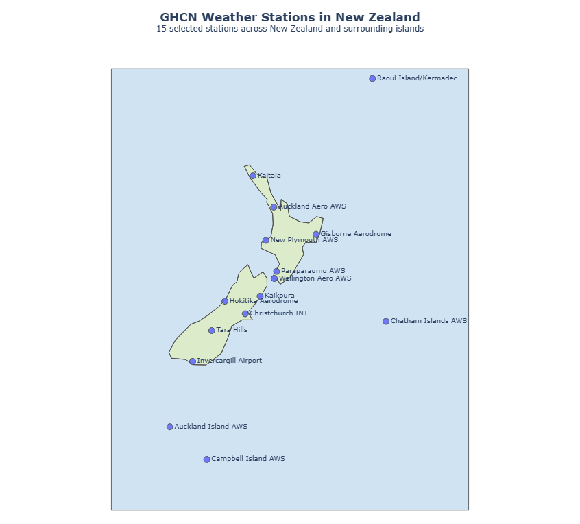

```python
import plotly.express as px
import pandas as pd

# =========================================================
# 1. Convert Spark DataFrame to Pandas
# =========================================================

nz_map_df = nz_stations.toPandas()

# =========================================================
# 2. Create station names using coordinates
# =========================================================

station_names = {
    (-52.550, 169.167): "Campbell Island AWS",
    (-50.483, 166.300): "Auckland Island AWS",
    (-46.417, 168.333): "Invercargill Airport",
    (-44.517, 169.900): "Tara Hills",
    (-43.950, -176.567): "Chatham Islands AWS",
    (-43.489, 172.532): "Christchurch INT",
    (-42.717, 170.983): "Hokitika Aerodrome",
    (-42.417, 173.700): "Kaikoura",
    (-41.333, 174.800): "Wellington Aero AWS",
    (-40.900, 174.983): "Paraparaumu AWS",
    (-39.017, 174.183): "New Plymouth AWS",
    (-38.650, 177.983): "Gisborne Aerodrome",
    (-37.000, 174.800): "Auckland Aero AWS",
    (-35.100, 173.267): "Kaitaia",
    (-29.250, -177.917): "Raoul Island/Kermadec"
}

# =========================================================
# 3. Match station names using latitude + longitude
# =========================================================

nz_map_df["STATION_NAME"] = [
    station_names.get(
        (round(lat, 3), round(lon, 3)),
        "Unknown Station"
    )
    for lat, lon in zip(
        nz_map_df["LATITUDE"],
        nz_map_df["LONGITUDE"]
    )
]

# =========================================================
# 4. VERIFY
# =========================================================

print("Total stations:", len(nz_map_df))
print("Named stations:", (nz_map_df["STATION_NAME"] != "Unknown Station").sum())
print("Unknown stations:", (nz_map_df["STATION_NAME"] == "Unknown Station").sum())

print("\nStation list:")
print(
    nz_map_df[
        ["ID", "STATION_NAME", "LATITUDE", "LONGITUDE"]
    ].sort_values("LATITUDE").to_string(index=False)
)

# =========================================================
# 5. Adjust longitude for antimeridian stations
# =========================================================

nz_map_df["PLOT_LONGITUDE"] = nz_map_df["LONGITUDE"].apply(
    lambda x: x + 360 if x < 0 else x
)

# =========================================================
# 6. Create map
# =========================================================

nz_station_map = px.scatter_geo(
    nz_map_df,

    lat="LATITUDE",
    lon="PLOT_LONGITUDE",

    # Station names displayed on map
    text="STATION_NAME",

    # Station name in hover
    hover_name="STATION_NAME",

    # Additional information
    hover_data={
        "ID": True,
        "LATITUDE": ":.3f",
        "LONGITUDE": ":.3f",
        "PLOT_LONGITUDE": False
    },

    projection="natural earth"
)

# =========================================================
# 7. Geographic styling
# =========================================================

nz_station_map.update_geos(
    showland=True,
    showocean=True,
    showcountries=True,
    showcoastlines=True,
    showlakes=True,

    landcolor="#DCECCB",
    oceancolor="#CFE3F2",
    lakecolor="#CFE3F2",
    coastlinecolor="#555555",

    # Centre around NZ
    center=dict(
        lat=-42,
        lon=176
    ),

    # Include all 15 stations
    lonaxis_range=[164, 190],
    lataxis_range=[-54, -27]
)

# =========================================================
# 8. Station markers and labels
# =========================================================

nz_station_map.update_traces(
    marker=dict(
        size=9,
        opacity=0.9,
        line=dict(width=1)
    ),

    textposition="middle right",

    textfont=dict(
        size=10
    )
)

# =========================================================
# 9. Professional title
# =========================================================

nz_station_map.update_layout(
    title=dict(
        text=(
            "<b>GHCN Weather Stations in New Zealand</b>"
            "<br>"
            "<sup>15 selected stations across New Zealand "
            "and surrounding islands</sup>"
        ),
        x=0.5,
        xanchor="center",
        y=0.96,
        yanchor="top"
    ),

    width=1100,
    height=750,

    margin=dict(
        l=20,
        r=20,
        t=100,
        b=20
    ),

    paper_bgcolor="white",
    plot_bgcolor="white"
)

# Display
nz_station_map.show()
```

### Saving The Result

```python
OUTPUT_PATH = (
    f"wasbs://{azure_user_container_name}"
    f"@{azure_account_name}.blob.core.windows.net/"
    f"{username}"
)

print(OUTPUT_PATH)

print(username)
```

```
wasbs://campus-user@madsstorage002.blob.core.windows.net/ama778
ama778
```

```python
NZ_PAIRS_OUTPUT = f"{OUTPUT_PATH}/nz_station_pair_distances"

nz_pairs.write.mode("overwrite").parquet(NZ_PAIRS_OUTPUT)

print("Saved to:")
print(NZ_PAIRS_OUTPUT)
```

```
26/09/08 17:40:26 WARN AzureFileSystemThreadPoolExecutor: Disabling threads for Delete operation as thread count 0 is <= 1
```

```
Saved to:
wasbs://campus-user@madsstorage002.blob.core.windows.net/ama778/nz_station_pair_distances
```

```
26/09/08 17:40:28 WARN AzureFileSystemThreadPoolExecutor: Disabling threads for Delete operation as thread count 0 is <= 1
```

```python
nz_pairs_saved = spark.read.parquet(NZ_PAIRS_OUTPUT)

print("Saved rows:", nz_pairs_saved.count())
nz_pairs_saved.printSchema()
```

```
Saved rows: 105
root
 |-- ID_1: string (nullable = true)
 |-- LATITUDE_1: double (nullable = true)
 |-- LONGITUDE_1: double (nullable = true)
 |-- ID_2: string (nullable = true)
 |-- LATITUDE_2: double (nullable = true)
 |-- LONGITUDE_2: double (nullable = true)
 |-- DISTANCE_KM: double (nullable = true)
```

### Q2 final answer

The pairwise geographical distances between all 15 New Zealand stations were calculated using the Haversine formula and saved as Parquet. This produced 105 unique station pairs. The geographically closest stations are NZ000093417 and NZM00093439, with a distance of approximately 50.53 km.

```python
stop_spark()
```

```
26/09/08 17:40:29 WARN ExecutorPodsWatchSnapshotSource: Kubernetes client has been closed.
```

**Spark**

The spark session is **stopped**, confirm that `ama778 (notebook)` is under the completed applications section in the Spark UI.

- [Spark UI](http://mathmadslinux2p.canterbury.ac.nz:8080/)